# CAS AN 102 PreClass Survey

Christopher A. Schmitt

9/29/2020

# About the Survey

In total, 76 students completed the survey, of 86 respondents. There are currently 95 students enrolled, so this covers about 80% of this semester’s students. Notably, it will not pick up any students who add or drop the course. Although I can figure out the responses of those who dropped post hoc, I can’t say anything about why students add the course once the semester has begun.

NOTE: the grey “chunks” below are the *R* code I’m using to bring in and analyze the results of the survey. If you have *R*, you can use this as a template for getting data from your own course surveys.

```r
survey <- read.csv("~/Desktop/AN102surveyFall2020.csv", sep=",", header=TRUE)
```

In the survey, the first line contains information on the data gathered, including each question the students are responding to (a LOT more data is gathered than intended, including the GPS location from where the survey was filled out!), the second line is a descriptor variable, and the third line is a “preview” survey I filled out, and starting in line 4 we get student responses.

We can summarize some statistics about sruvey use with these data. For example, how long it took students, in minutes, to respond to the survey:

```r
summary((as.numeric(survey$Duration..in.seconds.))/60)
```

```
##     Min.  1st Qu.   Median     Mean  3rd Qu.     Max.     NA's
##    0.283    4.383    8.100   67.730   13.967 3473.067        2
```

The most common length of time it took to complete the survey was 8 minutes, but the average was 68 minutes (brought up, no doubt, by one student who clearly started the survey and left it open in a tab for about 2.5 days). We can also graph this, if we like (limiting what we see to those responses that took less than 100 minutes):

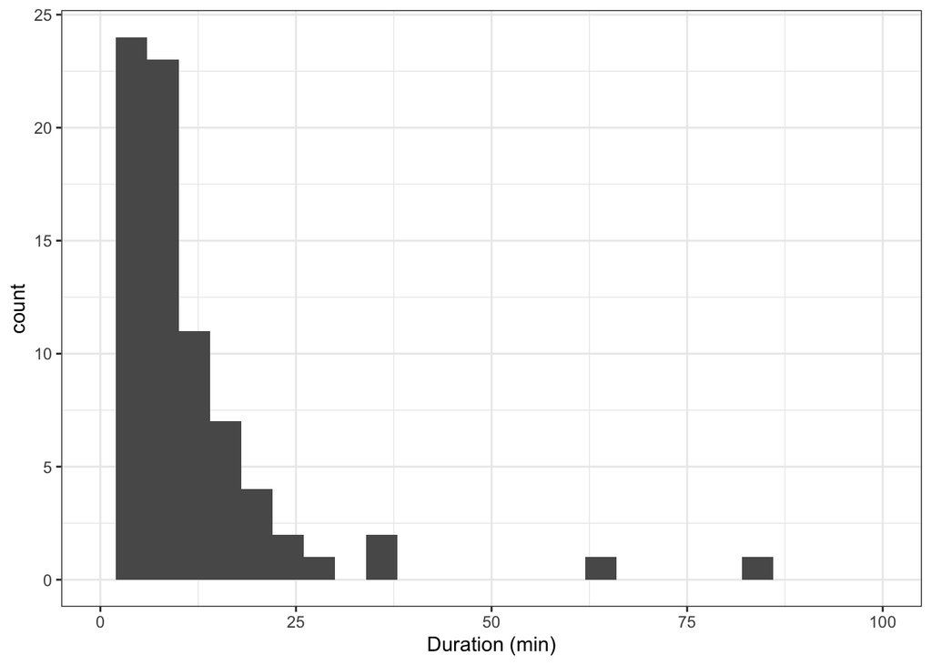

```r
library(ggplot2)
duration<-ggplot(survey,aes(x=as.numeric(Duration..in.seconds.)/60))+geom_histogram(binwidth = 4)+theme_bw()+xlim(0,100)+xlab("Duration (min)")
print(duration)
```

# Survey Response Table

So now I’m going to filter out my own responses, and also get rid of some of the columns I’m not currently interested in (note that this will only happen in the *R* space; the original data file remains complete). For example, I also collected names and preferred pronouns, but filtered them out for anonymity. Note that, in using the {DT} package’s *datatable* command, I’ve created a more flexible, and searchable, table for you to interact with in this file.

```r
library(tidyverse)
library(DT)
surveyq <-
  survey %>%
  filter(DistributionChannel != "preview") %>%
  select(Q2,Q1:Q14)
datatable(surveyq)
```

|  | Q2 | Q1 | Q5 | Q6 | Q7 | Q10 | Q11 | Q12 | Q13 | Q14 |
| --- | --- | --- | --- | --- | --- | --- | --- | --- | --- | --- |
| 1 | Welcome to the Fall 2020 semester of CAS AN 102: Human Biology, Behavior, and Evolution! I'm your instructor for the semester, Prof. Christopher Schmitt. As with most courses, CAS AN 102 will be a bit… | Under BU's Learn from Anywhere plan, you are permitted three ways of attending Lecture for CAS AN 102: in person, remote and synchronous, and remote and asynchronous. Note that, depending on the numbe… | Laboratory sections for CAS AN 102 under Learn from Anywhere will be conducted like a flipped classroom. All lab materials will be available on the course Blackboard site, in which each lab will have … | In which Laboratory Section are you currently enrolled? | If it were an option, would you be interested and willing to change sections if it meant you or another student would have the option of attending more lab sections in person? Please answer this quest… | If you are willing and able to do so, to which lab sections would your current schedule permit you to enroll in as an alternative to your current lab section? Please answer this question even if you c… | As your instructor, it helps me know the motivation behind my students' taking my course, so that I may better provide suitable instruction, and also better cater the course materials to student inter… | If so, which of the following academic requirements this course fulfills convinced you to enroll? You may choose more than one. | Aside from academic requirements, what about the course convinced you to enroll? | How did you hear about this course prior to deciding to enroll? You may choose more than one. |
| 2 | {"ImportId":"QID2_TEXT"} | {"ImportId":"QID1"} | {"ImportId":"QID5"} | {"ImportId":"QID6"} | {"ImportId":"QID7"} | {"ImportId":"QID10"} | {"ImportId":"QID11"} | {"ImportId":"QID12"} | {"ImportId":"QID13_TEXT"} | {"ImportId":"QID14"} |
| 3 | U68216557 | I would prefer to attend In Person | I would prefer to attend In Person | CAS AN 102 A5 (Tuesdays 9:00am - 10:45pm) | Yes | CAS AN 102 A9 (Thursdays 9:00am - 10:45am) | Yes | GenEd: NS Lab requirement | I really want to expand my scope of knowledge about anthropology and learn about where we came from! | I found it while searching for courses that would fulfill my BU Hub requirements |
| 4 | U17910228 | I would prefer to attend In Person | I would prefer to attend In Person | CAS AN 102 A2 (Mondays 12:20pm - 2:05pm) | Yes | My schedule does not permit me to change my lab section due to conflicts with other courses. | Yes | BU Hub: Scientific Inquiry 1 (SI1),BU Hub: Critical Thinking (CRT),Required for my major (Biological Anthropology Track) | I have taken Cultural and Social Anthropology at my high school for two years through the IB program. I immediately fell in love with the topic however, loved biology and ecology so my teacher recomme… | I found it while searching for courses that would fulfill my BU Hub requirements |
| 5 | U06274939 | I would prefer to attend In Person | I would prefer to attend In Person | CAS AN 102 A2 (Mondays 12:20pm - 2:05pm) | Yes | CAS AN 102 A6 (Wednesdays 12:20pm - 2:05pm) | Possibly, I'm not sure yet | BU Hub: Scientific Inquiry 1 (SI1) | I thought it would be an interesting topic and I want to explore different studies/ possible majors. | I found it in the CAS Bulletin |
| 6 | U26076009 | I would prefer to attend In Person | I would prefer to attend In Person | CAS AN 102 A2 (Mondays 12:20pm - 2:05pm) | Yes | CAS AN 102 A6 (Wednesdays 12:20pm - 2:05pm) | Possibly, I'm not sure yet | This course fulfills a prerequisite for another course I want to take |  | I found it in the CAS Bulletin |
| 7 | U38922989 | I would prefer to attend Remotely and Synchronously | I would prefer to attend Remotely and Synchronously | CAS AN 102 A2 (Mondays 12:20pm - 2:05pm) | No | My schedule does not permit me to change my lab section due to conflicts with other courses. | No | This course will not fulfill any of my academic requirements | i am just intersted in this course. | I found it in the CAS Bulletin |
| 8 | U83980967 | I would prefer to attend In Person | I would prefer to attend In Person | CAS AN 102 A2 (Mondays 12:20pm - 2:05pm) | No | CAS AN 102 A2 (Mondays 12:20pm - 2:05pm) | Yes | BU Hub: Scientific Inquiry 1 (SI1),BU Hub: Social Inquiry 1 (SO1) | I really enjoyed biology in high school and wanted to continue learning about it. | I found it in the CAS Bulletin,I found it while searching for courses that would fulfill my BU Hub requirements |
| 9 | U75367741 | I would prefer to attend In Person | I would prefer to attend In Person | CAS AN 102 A5 (Tuesdays 9:00am - 10:45pm) | Yes | CAS AN 102 A2 (Mondays 12:20pm - 2:05pm),CAS AN 102 A9 (Thursdays 9:00am - 10:45am) | Yes | Required for my major (Biological Anthropology Track) | The similarities and differences between humans and primates and the evolution of the two interests me. | I found it while searching for courses that would fulfill my BU Hub requirements,My advisor recommended the course |
| 10 | U54370966 | I would prefer to attend In Person | I would prefer to attend In Person | CAS AN 102 A2 (Mondays 12:20pm - 2:05pm) | No | My schedule does not permit me to change my lab section due to conflicts with other courses. | Yes | Required for my major (Cultural Anthropology Track),This course fulfills a prerequisite for another course I want to take | I looked up Professor Schmitt and he struck me as not only an intelligent individual, but also as someone who would be an attentive and compassionate professor; all qualities that are essential in com… | My advisor recommended the course |

[output cut: 81 more lines]

Now, there are some questions I asked that are summarizable, and some that aren’t. I’ll summarize with figures those questions that I can.

# Attendance Preferences under L*f*A

## Lecture

For example, Q1 asks their preferred mode of attending lecture. The responses were:

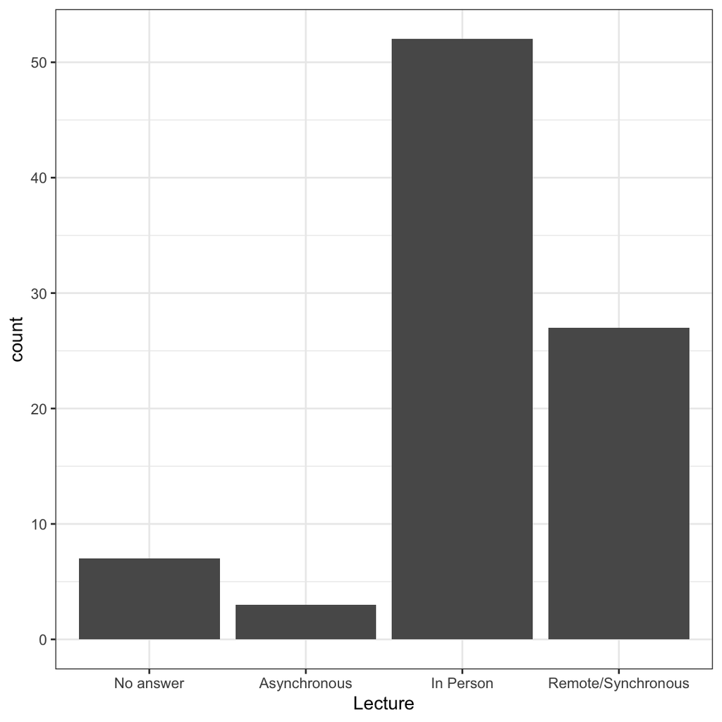

```r
lecture<-ggplot(surveyq[c(3:91),],aes(x=Q1))+geom_bar()+theme_bw()+scale_x_discrete("Lecture",labels = c('No answer','Asynchronous','In Person','Remote/Synchronous'))
print(lecture)
```

## Labs

For labs (question Q5), the outcome was pretty similar (albeit, interestingly, with more students preferring asynchronous labs):

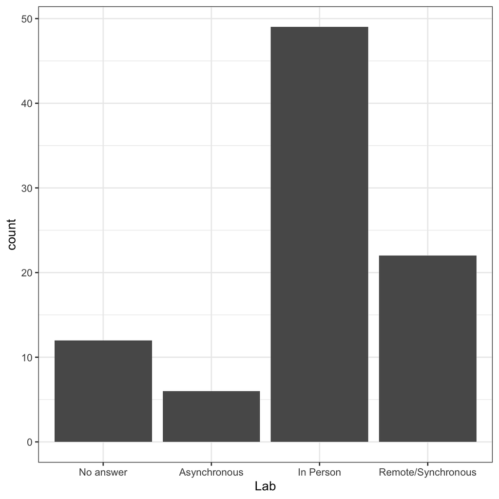

```r
labs<-ggplot(surveyq[c(3:91),],aes(x=Q5))+geom_bar()+theme_bw()+scale_x_discrete("Lab",labels = c('No answer','Asynchronous','In Person','Remote/Synchronous'))
print(labs)
```

I wondered if those who have early morning labs were the ones who would have preferred asynchronous lab attendance… we can see if this choice corresponds to their lab section using the following graph:

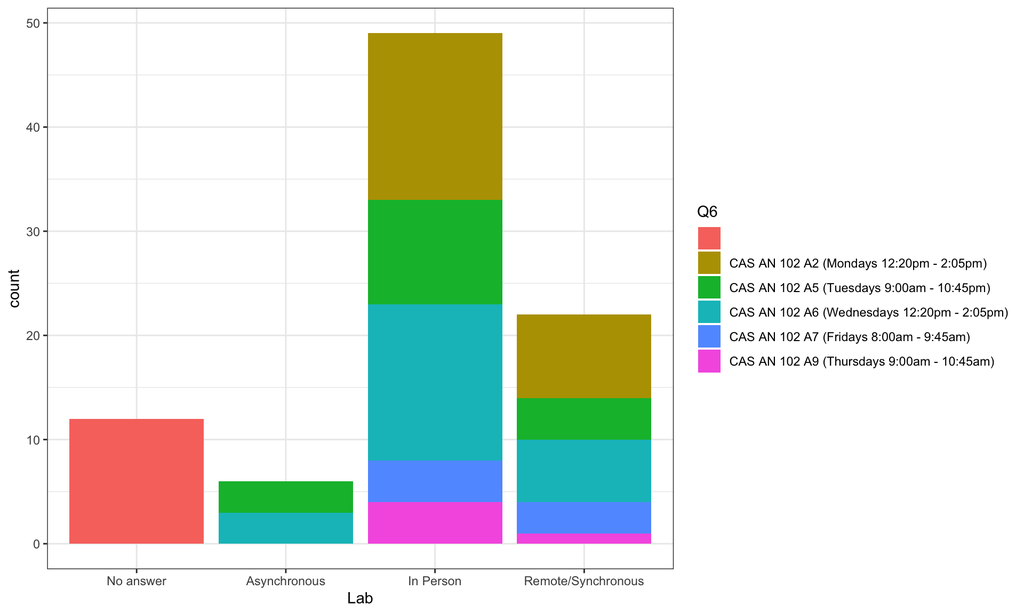

```r
labs<-ggplot(surveyq[c(3:91),],aes(x=Q5,fill=Q6))+geom_bar()+theme_bw()+scale_x_discrete("Lab",labels = c('No answer','Asynchronous','In Person','Remote/Synchronous'))
print(labs)
```

As the graph shows, early morning sections appear not to be a factor.

When asked if students would be interested and willing to change their section time, if it meant more students attending in person:

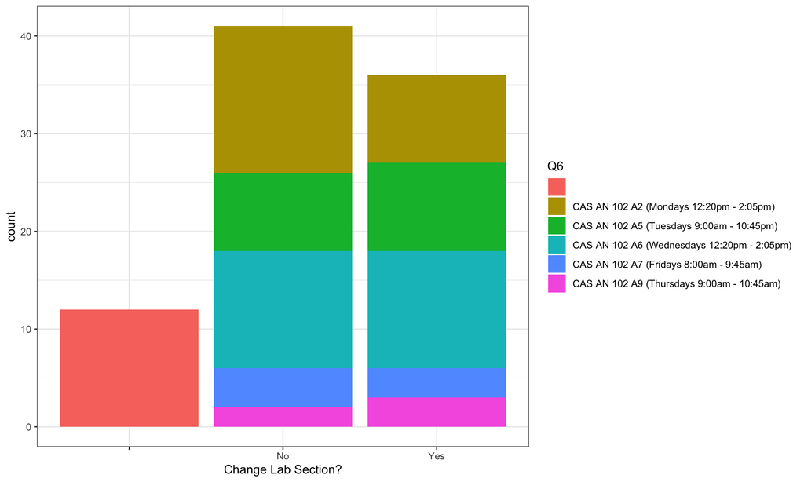

```r
labs<-ggplot(surveyq[c(3:91),],aes(x=Q7,fill=Q6))+geom_bar()+theme_bw()+scale_x_discrete("Change Lab Section?")
print(labs)
```

No big differences based on currently enrolled section, although it would appear that, based on willingness to change, the A2 lab (Mondays 12:20-2:05pm) is the most desirable, and the 9:00am labs (A5, A9) are perhaps the least desirable.

Let’s dig into this more with the results when asked which lab section they would prefer to change in to given the option of making a change. The answers are mixed, no doubt based on individual schedules. Note that Q7 asks if they would change given the option:

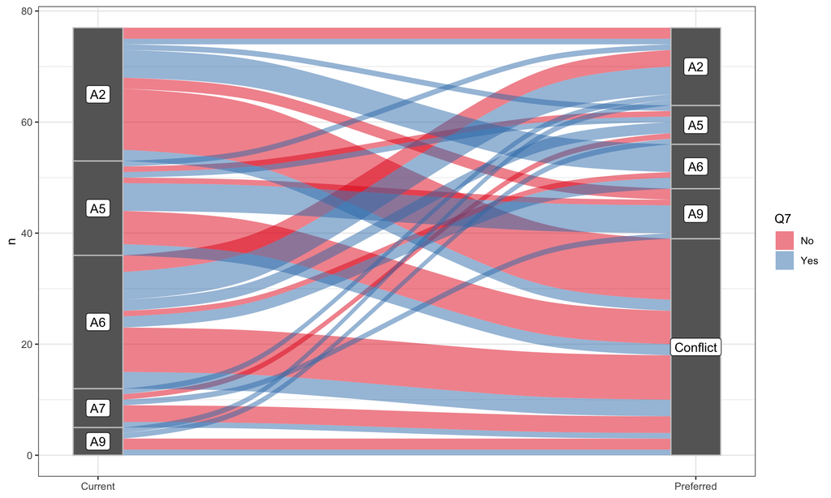

```r
surveyq.long <-
  surveyq[c(3:91),] %>%
  as_tibble() %>%
  select(Q6,Q7,Q10) %>%
  mutate(Q6 = str_replace_all(Q6, pattern = c(".*A2.*" = "A2",".*A5.*" = "A5",".*A6.*" = "A6",".*A7.*" = "A7",".*A9.*" = "A9"))) %>%
  mutate(Q10 = str_replace_all(Q10, pattern = c("My schedule does not permit me to change my lab section due to conflicts with other courses." = "Conflict",".*A2.*" = "A2",".*A5.*" = "A5",".*A6.*" = "A6",".*A7.*" = "A7",".*A9.*" = "A9"))) %>%
  na_if(., "") %>%
  na.omit() %>%
  group_by(Q7,Q6,Q10) %>%
  tally()

library(ggalluvial)

ggplot(surveyq.long,
       aes(y = n, axis1 = Q6, axis2 = Q10)) +
  geom_alluvium(aes(fill = Q7), width = 1/12) +
  geom_stratum(width = 1/12, fill = "grey40", color = "grey80") +
  geom_label(stat = "stratum", aes(label = after_stat(stratum))) +
  scale_x_discrete(limits = c("Current", "Preferred"), expand = c(.05, .05)) +
  scale_fill_brewer(type = "qual", palette = "Set1") + theme_bw()
```

# Why are Fall2020 students taking AN 102?

Here’s the important part! The overwhelming primary answer appears to be: **graduation or major requirements**.

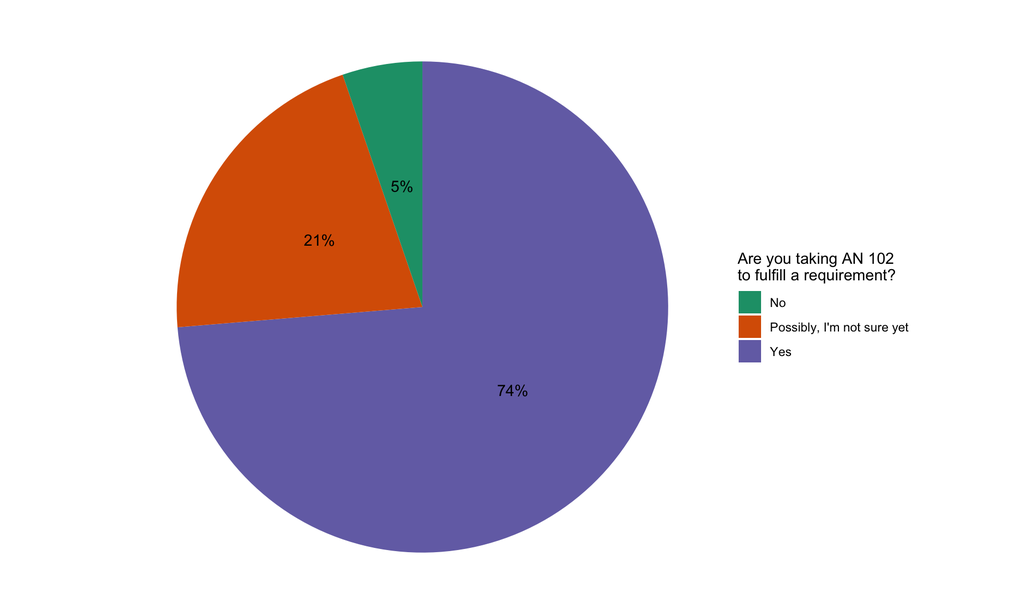

```r
surveyq.why <-
  surveyq[c(3:91),] %>%
  as_tibble() %>%
  select(Q11) %>%
  na_if(., "") %>%
  na.omit() %>%
  droplevels() %>%
  group_by(Q11) %>%
  tally() %>%
  arrange(desc(Q11)) %>%
  mutate(prop = n/sum(n)*100) %>%
  mutate(ypos = cumsum(prop) - 0.5*prop)

percent <- function(x, digits = 0, format = "f", ...) {
  paste0(formatC(100 * x, format = format, digits = digits, ...), "%")
}

bp <- ggplot(surveyq.why, aes(x="", y=prop, fill=Q11))+
geom_bar(width = 1, stat = "identity")

pieQ11 <- bp + coord_polar("y", start=0) + scale_fill_brewer(palette="Dark2") + theme_void() + theme(axis.text.x=element_blank()) + labs(fill = "Are you taking AN 102\nto fulfill a requirement?") + geom_text(aes(y = ypos,label = percent(n/76)))
pieQ11
```

So ok… the majority of our students are fulfilling a requirement… but which ones (students were allowed to choose more than one)?

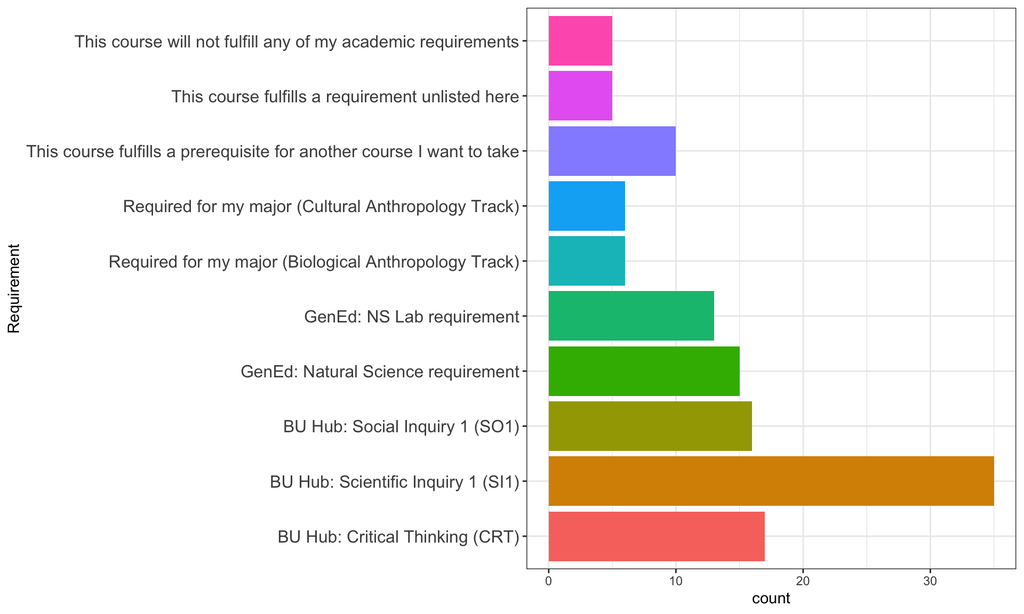

```r
surveyq.why2 <-
  surveyq[c(3:91),] %>%
  as_tibble() %>%
  select(Q12) %>%
  na_if(., "") %>%
  na.omit() %>%
  mutate(Q12 = strsplit(as.character(Q12), ",")) %>%
  unnest(Q12) %>%
  droplevels()

requirements <- ggplot(surveyq.why2,aes(x=Q12,fill=Q12)) + geom_bar()+theme_bw() + scale_x_discrete("Requirement") + theme(axis.text.y = element_text(size=12)) + theme(legend.position = "none") + coord_flip()
print(requirements)
```

By far the most important requirements are associated with the Hub, underscoring the importance of these requirements to enrollments in future. The most important by far is Scientific Inquiry 1 (about 50% of students are taking the course to fulfill this requirement), followed by Critical Thinking, followed by Social Inquiry 1. If we did decide to change the Hublets for this course to stimulate enrollment, it should be either Critical Thinking or Social Inquiry 1… although these hublets still represent roughly 20% of enrollments

Among senior enrollments, it would appear the NS and NS Lab requirements are alive and well, and account for the next two most important requirements. These are followed by Anthropology departmental requirements, including for majors and pre-requisites. There appear to be some requirements I hadn’t thought of, but overall, very few students are taking the course without requirements in mind. I unfortunately did not ask for their year in school or their major (I can’t believe I neglected to ask this, silly oversight), but could reconstruct these by matching student records with the survey based on student ID number if we think those data would be important.

I also asked how students heard about or found out about AN 102 prior to enrolling:

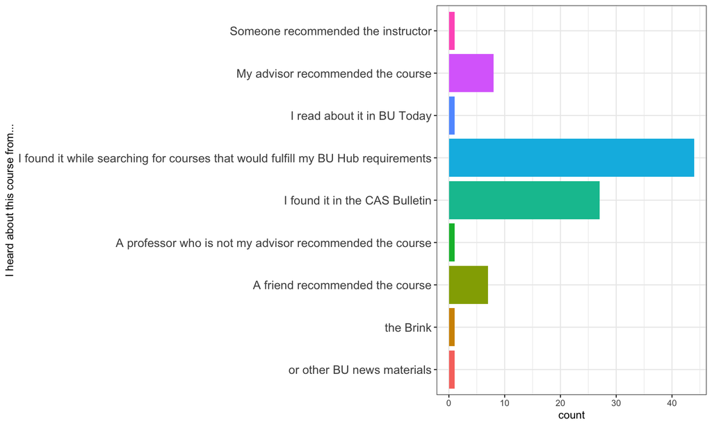

```r
surveyq.why3 <-
  surveyq[c(3:91),] %>%
  as_tibble() %>%
  select(Q14) %>%
  na_if(., "") %>%
  na.omit() %>%
  mutate(Q14 = strsplit(as.character(Q14), ",")) %>%
  unnest(Q14) %>%
  droplevels()

referral <- ggplot(surveyq.why3,aes(x=Q14,fill=Q14)) + geom_bar()+theme_bw() + scale_x_discrete("I heard about this course from...") + theme(axis.text.y = element_text(size=12)) + theme(legend.position = "none") + coord_flip()
print(referral)
```

In this case, it is overwhelmingly clear that at this point our courses really *need* to be listed in the Hub to be noticed, and that students are finding courses based explicitly on the Hublets and combination of Hublets offered. A second clear takeaway is that our Bulletin text is drawing students in, and so we need that text be noticeable, appealing, and on point for all our courses. Aside from these two major factors, it would appear that the next most important ways students find AN 102 is by word of mouth, which is nice to know.

Finally, I asked students what they wanted to get out of taking the class (aside from requirements). Below are the responses. My impression is that this is about what we would expect. A major theme is that the students see biological anthropology as a way of combining their interest in biology with their interests or specialties in social sciences/humanities (or a way to study biology without diving into the biology curriculum, which these students appear to find challenging); I think this is a good strength to promote (and which the Medical specialization will push even more strongly). A lot of students also appear interested in majoring or minoring, which is great, and highlights this course as a gateway to the major. We have at least one senior who chose this course because it fulfills the NS lab requirement but feels more like a social science (an echo of what we think might explain the precipitous enrollment drop under the Hub). We also have quite a few Psychology majors who are looking for something other than psychology as a blend of the social sciences and biology… Carolyn is obviously in a good position to exploit this (and perhaps these students heard about it through her presence in Psychology).

```r
hopes <-
  surveyq[c(3:91),c(1,9)] %>%
  na_if(., "") %>%
  na.omit() %>%
  droplevels()
datatable(hopes)
```

|  | Q2 | Q13 |
| --- | --- | --- |
| 3 | U68216557 | I really want to expand my scope of knowledge about anthropology and learn about where we came from! |
| 4 | U17910228 | I have taken Cultural and Social Anthropology at my high school for two years through the IB program. I immediately fell in love with the topic however, loved biology and ecology so my teacher recomme… |
| 5 | U06274939 | I thought it would be an interesting topic and I want to explore different studies/ possible majors. |
| 7 | U38922989 | i am just intersted in this course. |
| 8 | U83980967 | I really enjoyed biology in high school and wanted to continue learning about it. |
| 9 | U75367741 | The similarities and differences between humans and primates and the evolution of the two interests me. |
| 10 | U54370966 | I looked up Professor Schmitt and he struck me as not only an intelligent individual, but also as someone who would be an attentive and compassionate professor; all qualities that are essential in com… |
| 11 | U05363274 | I took NE 101 in the spring of 2020. We had a unit on evolutionary biology and neuroscience and I was fascinated about the complexity of other species. In particular, the intelligence of other species… |
| 12 | U29067916 | I like the idea of getting to know more about biology and I love science and but my current major doesn’t involve science. |
| 13 | U38618491 | My schedule had an empty block due to my language fulfillment, and I wanted to fill it with some general science course. Plus, all the general psych courses were either full or interfered with my sche… |

[output cut: 56 more lines]

# Takeaways from the survey

First off, problems with Qualtrics aside, this seems like a great mechanisms by which to gather good information about the state of our courses, and how students are perceiving them. I plan to incorporate this into AN 102 in future semesters, as well, to build up a database of responses (that will be anonymized upon pooling) to be used strictly for internal purposes.

This should also help with decision-making regarding course content and provides some potential directions for change, should we choose. It sounds like students primarily take AN 102 to fulfill requirements (especially SI1 in the Hub; and the NS Lab requirement for seniors), although the student comments on why they chose the course reveal an array of reasons that suggest clear areas in which to emphasize/advertise the major to perhaps get more enrollments (e.g., psychology; humanities and social science majors that might be interested in biology). Right now, the primary ways in which students are hearing about AN 102 is via the BU Hub search engine and the CAS Bulletin, followed by word of mouth. Questions this brings up are: are there other avenues by which we can advertise ourselves around campus? Also, are there ways to make these primary avenues increase enrollments further? Perhaps this can guide our discussion.